# COVID-19 Data Analysis

Adrian Garcia

2023-02-23

# Introduction

Over the course of the COVID-19 pandemic, we have seen many variations of state government mandates issued to mitigate the spread of the disease as well as different states having varying levels of stringency of such mandates throughout the pandemic. Thus, the goal of this project is to research to what extent did these mandates, and how stringent these were varied, affect how fast the disease spread across the US. To do this, we will be using the “United States COVID-19 Cases and Deaths by State over Time” data set from the CDC (“https://data.cdc.gov/Case-Surveillance/United-States-COVID-19-Cases-and-Deaths-by-State-o/9mfq-cb36”); in which, contains 15 characteristics and 60,000 samples listed below.

```r
# Packages
library(data.table)
# Load Data
covid_df <- fread("COVID19.csv", data.table = FALSE)
str(covid_df)
```

```
## 'data.frame':    60060 obs. of  15 variables:
##  $ submission_date: chr  "03/11/2021" "12/01/2021" "01/02/2022" "11/22/2021" ...
##  $ state          : chr  "KS" "ND" "AS" "AL" ...
##  $ tot_cases      : int  297229 163565 11 841461 251425 0 173 173967 0 602931 ...
##  $ conf_cases     : int  241035 135705 NA 620483 NA 0 NA 144788 NA NA ...
##  $ prob_cases     : int  56194 27860 NA 220978 NA 0 NA 29179 NA NA ...
##  $ new_case       : int  0 589 0 703 0 0 14 667 0 1509 ...
##  $ pnew_case      : int  0 220 0 357 0 0 NA 274 0 0 ...
##  $ tot_death      : int  4851 1907 0 16377 1252 0 3 2911 0 8318 ...
##  $ conf_death     : int  NA NA NA 12727 NA 0 NA 2482 NA NA ...
##  $ prob_death     : int  NA NA NA 3650 NA 0 NA 429 NA NA ...
##  $ new_death      : int  0 9 0 7 0 0 0 8 0 6 ...
##  $ pnew_death     : int  0 0 0 3 0 0 NA 3 0 0 ...
##  $ created_at     : chr  "03/12/2021 03:20:13 PM" "12/02/2021 02:35:20 PM" "01/03/2022 03:18:16 PM" "11/22/2021 12:00:00 AM" ...
##  $ consent_cases  : chr  "Agree" "Agree" "" "Agree" ...
##  $ consent_deaths : chr  "N/A" "Not agree" "" "Agree" ...
```

# Findings

In using the aforementioned data set, we will be testing 4 hypotheses. (1) Larger populated states saw more total cases and deaths than smaller states, regardless of mandate strictness. (2/3) Lax COVID-19 restricted states had a greater number of new/total cases per 100,000 than stricter states. (4) The top five largest states accounted for half of the new cases in the US.

To expand further, we will: (1) plot the total number of cases vs total number of deaths per state on a log scale, then fit this data through a linear model, (2/3) plot new/total cases over time (per 100,000) for US states Iowa, South Carolina, Virginia, and Vermont,

(these states were chosen specifically because they were ranked the two most lax and the two most strict states in regards to COVID-19 mandates, respectively. “https://www.beckershospitalreview.com/rankings-and-ratings/states-ranked-by-covid-19-restrictions.html”)

and (4) perform a one-sample z-test to determine if hypothesis (4) is correct.

Now, first let us consider hypothesis (1). In an effort to clean the data, the data set was read and sorted such that only the last submission date for each US state was considered. As a result, a scatter plot was generated containing 50 data points representing each US state. Additionally, to fit the data through a linear model, `geom_smooth(method = 'lm')` (as well as `lm(log(tot_death) ~ log(tot_cases), covid_df1)`) was used. Consequently, we have the following figure,

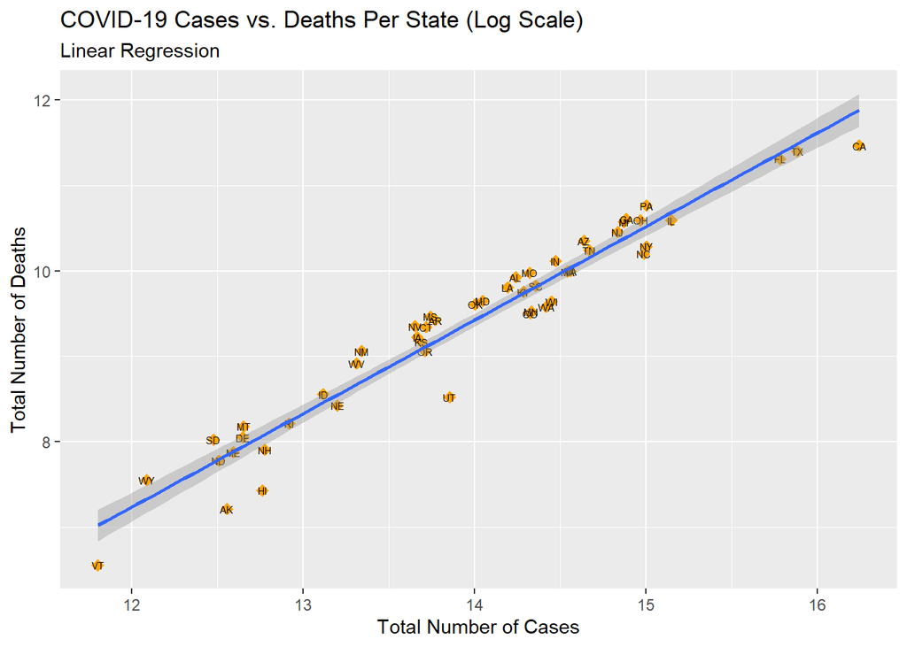

```r
# Packages
library(ggplot2)
library(dplyr)
states <- c("AK", "AL", "AR", "AZ", "CA", "CO", "CT", "DE", "FL", "GA",
           "HI", "IA", "ID", "IL", "IN", "KS", "KY", "LA", "MA", "MD",
           "ME", "MI", "MN", "MO", "MS", "MT", "NC", "ND", "NE", "NH",
           "NJ", "NM", "NV", "NY", "OH", "OK", "OR", "PA", "RI", "SC",
           "SD", "TN", "TX", "UT", "VA", "VT", "WA", "WI", "WV", "WY")
# Data Cleaning
covid_df$submission_date <- as.Date(covid_df$submission_date, format = "%m/%d/%Y")
covid_df <- arrange(covid_df, state, submission_date)
covid_df1 <- covid_df[!rev(duplicated(rev(covid_df$state))),]
covid_df1 <- covid_df1[covid_df1$state %in% states,]
# Plot
plt1 <- ggplot(data = covid_df1,
              aes(x = log(tot_cases), y = log(tot_death))) +
              geom_point(color = "orange", size = 3, shape = 18) +
              ggtitle(label = "COVID-19 Cases vs. Deaths Per State (Log Scale)", subtitle = "Linear Regression") +
              xlab("Total Number of Cases") + ylab("Total Number of Deaths") +
              geom_text(data = covid_df1, aes(label = state), size = 2) +
              geom_smooth(method = "lm")
plt1
```

```r
# SLM Results
fit <- lm(log(tot_death) ~ log(tot_cases), covid_df1)
summary(fit)
```

```
##
## Call:
## lm(formula = log(tot_death) ~ log(tot_cases), data = covid_df1)
##
## Residuals:
##      Min       1Q   Median       3Q      Max
## -0.74281 -0.11405  0.08184  0.21056  0.35616
##
## Coefficients:
##                Estimate Std. Error t value Pr(>|t|)
## (Intercept)    -5.92693    0.53370  -11.11 7.33e-15 ***
## log(tot_cases)  1.09652    0.03813   28.76  < 2e-16 ***
## ---
## Signif. codes:  0 '***' 0.001 '**' 0.01 '*' 0.05 '.' 0.1 ' ' 1
##
## Residual standard error: 0.2687 on 48 degrees of freedom
## Multiple R-squared:  0.9451, Adjusted R-squared:  0.944
## F-statistic:   827 on 1 and 48 DF,  p-value: < 2.2e-16
```

Second, let us consider hypotheses (2/3). We first subdivided each state (Iowa, South Carolina, Vermont, Virginia) into an individual data set, then sorted by submission date. However, to get a better representation of the data, we normalized each state’s data set by dividing by its respective population size and multiplying by 100,000; resulting in the following figures.

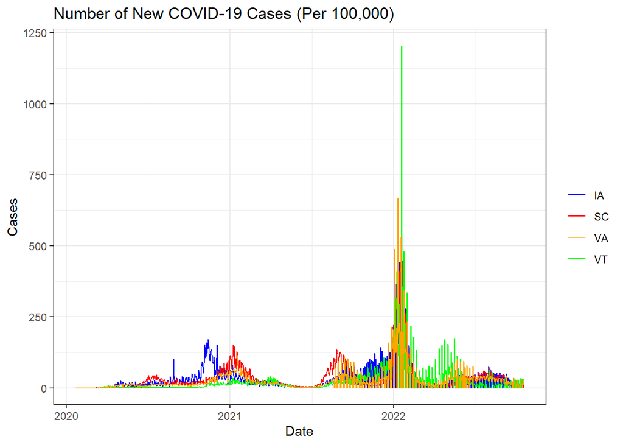

```r
# Data Subsets
IA <- covid_df[covid_df$state %in% c("IA"),]
IA$new_case <- (IA$new_case / 3190369) * 100000
SC <- covid_df[covid_df$state %in% c("SC"),]
SC$new_case <- (SC$new_case / 5118425) * 100000
VT <- covid_df[covid_df$state %in% c("VT"),]
VT$new_case <- (VT$new_case / 643077) * 100000
VA <- covid_df[covid_df$state %in% c("VA"),]
VA$new_case <- (VA$new_case / 8631393) * 100000
# Plot
legend_colors <- c("IA" = "blue", "SC" = "red", "VT" = "green", "VA" = "orange")
plt2 <- ggplot() +
        geom_line(data = IA, aes(x = submission_date, y = new_case, color = "IA")) +
        geom_line(data = SC, aes(x = submission_date, y = new_case, color = "SC")) +
        geom_line(data = VT, aes(x = submission_date, y = new_case, color = "VT")) +
        geom_line(data = VA, aes(x = submission_date, y = new_case, color = "VA")) +
        ggtitle(label = "Number of New COVID-19 Cases (Per 100,000)") +
        xlab("Date") + ylab("Cases") +
        labs(color = " ") +
        scale_color_manual(values = legend_colors) +
        theme_bw()
plt2
```

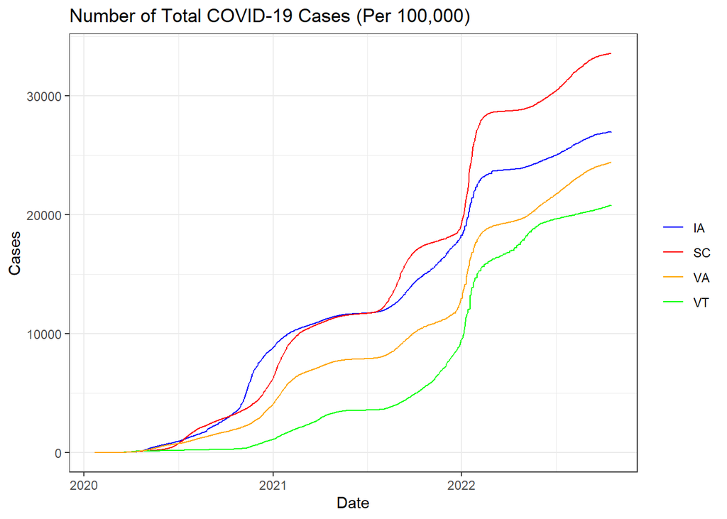

```r
# Data Subsets
IA$tot_cases <- (IA$tot_cases / 3190369) * 100000
SC$tot_cases <- (SC$tot_cases / 5118425) * 100000
VT$tot_cases <- (VT$tot_cases / 643077) * 100000
VA$tot_cases <- (VA$tot_cases / 8631393) * 100000
# Plot
plt3 <- ggplot() +
        geom_line(data = IA, aes(x = submission_date, y = tot_cases, color = "IA")) +
        geom_line(data = SC, aes(x = submission_date, y = tot_cases, color = "SC")) +
        geom_line(data = VT, aes(x = submission_date, y = tot_cases, color = "VT")) +
        geom_line(data = VA, aes(x = submission_date, y = tot_cases, color = "VA")) +
        ggtitle(label = "Number of Total COVID-19 Cases (Per 100,000)") +
        xlab("Date") + ylab("Cases") +
        labs(color = " ") +
        scale_color_manual(values = legend_colors) +
        theme_bw()
plt3
```

For the first figure above, we see that hypothesis (2) is correct from 2020 till the latter half of 2021; on the other hand, it is interesting to note the significant spike in new cases close to January 2022 causes hypothesis (2) to be incorrect as Vermont, a stricter state, has a much larger spike than the other states. We may then conclude that hypothesis (2) is correct if strict states remain as such. Now, for the second figure above, we see that hypothesis (3) is undoubtedly correct as both Iowa and South Carolina have a greater number of total cases than Vermont and Virginia, even with the aforementioned spike in the previous figure.

Finally, let us consider hypothesis (4). We again subdivided each state (California, Texas, New York, Florida, and Pennsylvania) into an individual data set, then summand all the new cases in each subdivided state into `num_in`, and similarly summand **all** new cases into `total`. We then run a one-sample z-test to determine if hypothesis (4) is correct.

```r
# Data Subsets
CA <- covid_df[covid_df$state %in% c("CA"),]
TX <- covid_df[covid_df$state %in% c("TX"),]
NY <- covid_df[covid_df$state %in% c("NY"),]
FL <- covid_df[covid_df$state %in% c("FL"),]
PA <- covid_df[covid_df$state %in% c("PA"),]
# One-sample z-test
num_in <- sum(CA$new_case) + sum(TX$new_case) + sum(NY$new_case) +
          sum(FL$new_case) + sum(PA$new_case)
total <- sum(covid_df$new_case)
prop.test(
  x = num_in,
  n = total,
  p = 0.5
)
```

```
##
##  1-sample proportions test with continuity correction
##
## data:  num_in out of total, null probability 0.5
## X-squared = 10082036, df = 1, p-value < 2.2e-16
## alternative hypothesis: true p is not equal to 0.5
## 95 percent confidence interval:
##  0.3380228 0.3382119
## sample estimates:
##         p
## 0.3381174
```

# Conclusion

To summarize our findings, we found that

hypothesis (2) is correct from 2020 till the latter half of 2021 thus hinting that hypothesis (2) is correct if strict states remain as such,

As a result, we may unsurprisingly conclude that state government issued mandates, and how stringent these were varied, very much affect how fast the disease spread across the state. However, it is significant to note that cases caused by COVID-19 in a state are not only determined by a state government’s response, but independent factors such as past health issues of an individual, age distribution of the population, access to personal protective equipment (PPE), and the population’s adherence to such mandates. Therefore, for possible future pandemics, we much act accordingly and implement safety mandates as soon as possible and adhere to them as best we can. If not, we may see spikes like we did in figure 2 once again. Additionally, the purpose of this project was to highlight how effective different levels of stringency was in mitigating the spread of COVID-19; however, independent factors such as the ones aforementioned should be analyzed in future work.